# Time

## Learning objectives

This topic focuses on time as a variable.

By the end of this topic you should be able to:

- Describe ways time can appear in data
- Characterize visualizations techniques for time data and models with time
- Describe statistical challenges of dealing with data taken over time

## Time in data or data over time?

Time can appear many ways in data:

- Repeated measures: the same subjects are measured at different times
- Time series: the same variable is measured at different times
- Difference: the difference in the same variable or subject measured at specific times

## Graphs with time

Generally any graph with time (days, weeks, years, etc.)

Most techniques you already know are applicable here

## Graphs with time

Time series graphs as a simple line plot

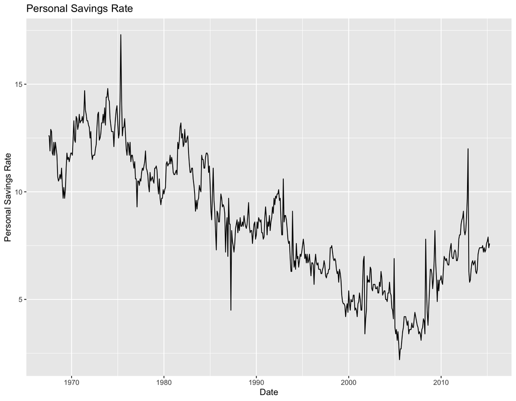

## Graphs with time

Time series graphs as a simple line plot plus

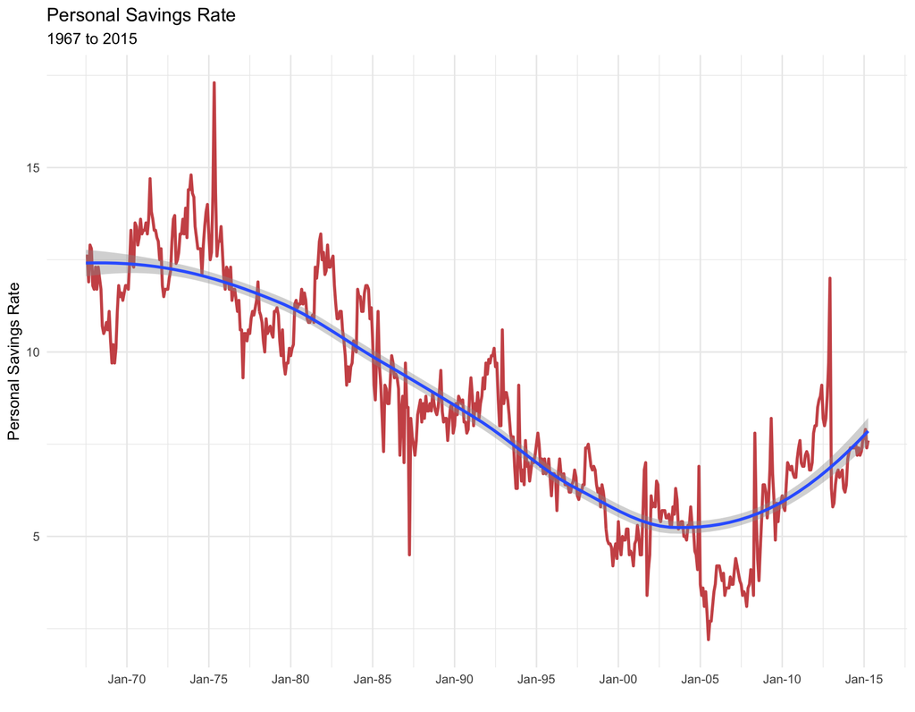

## Graphs with time

Area

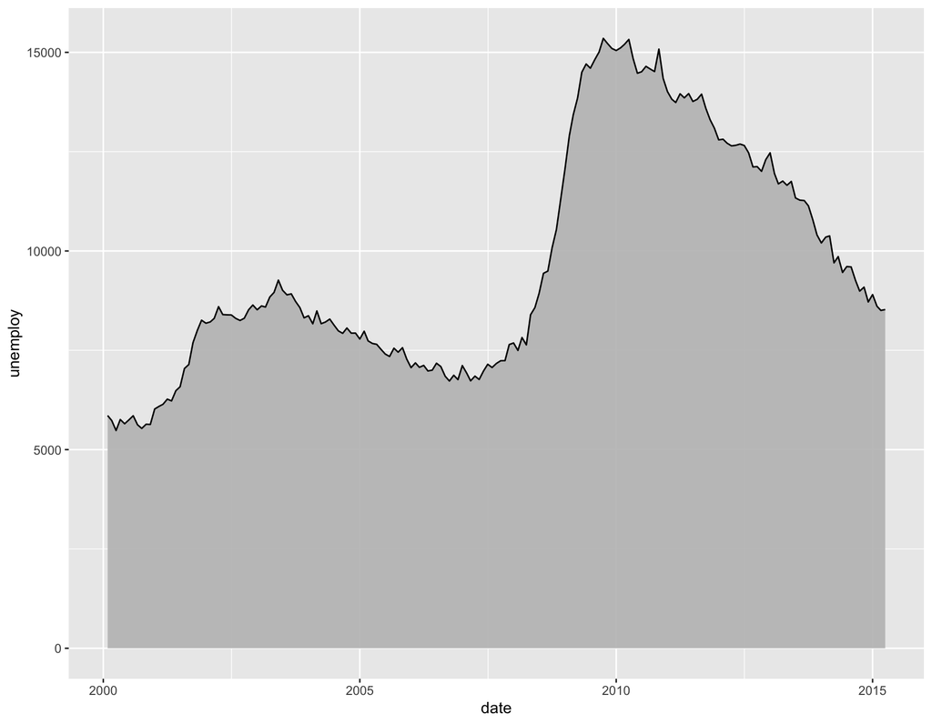

## Graphs with time

Facets

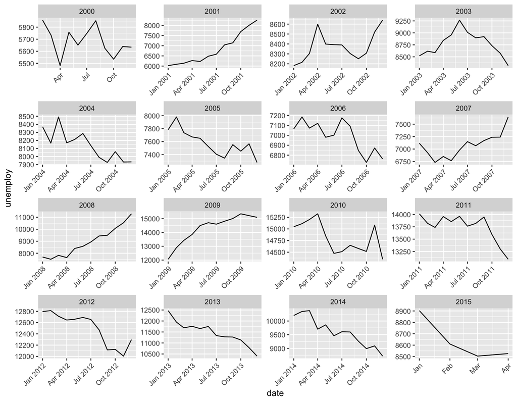

## Graphs with time

Multivariate, i.e. more than one data

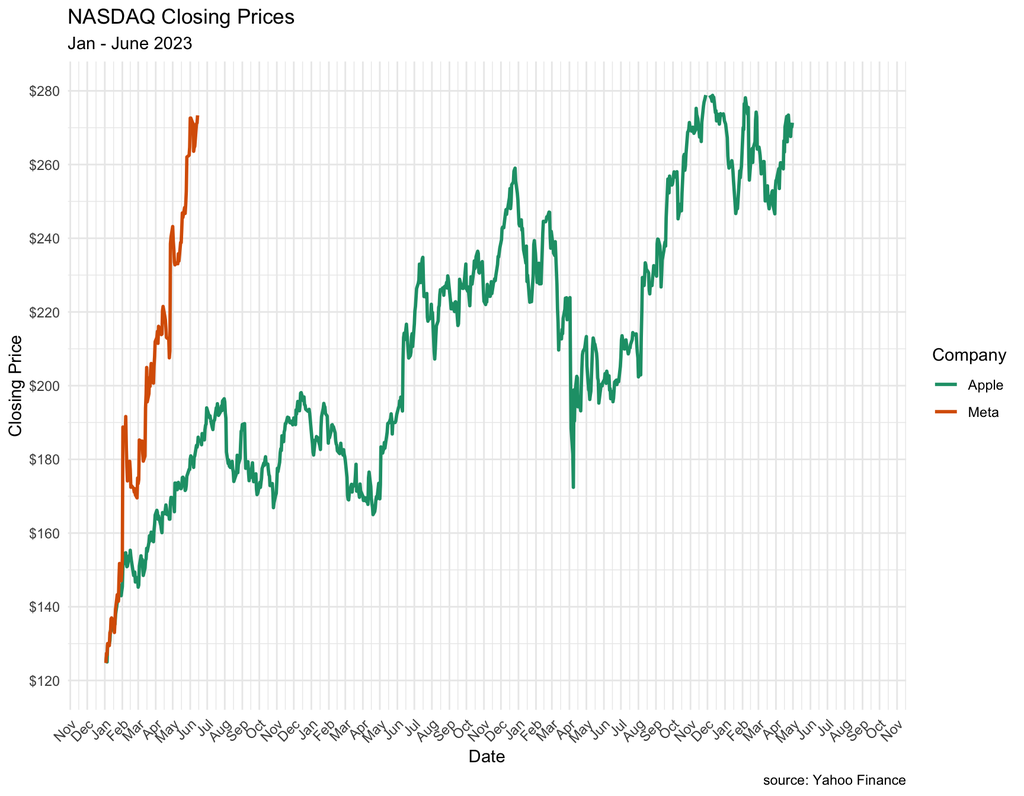

## Visual challenges

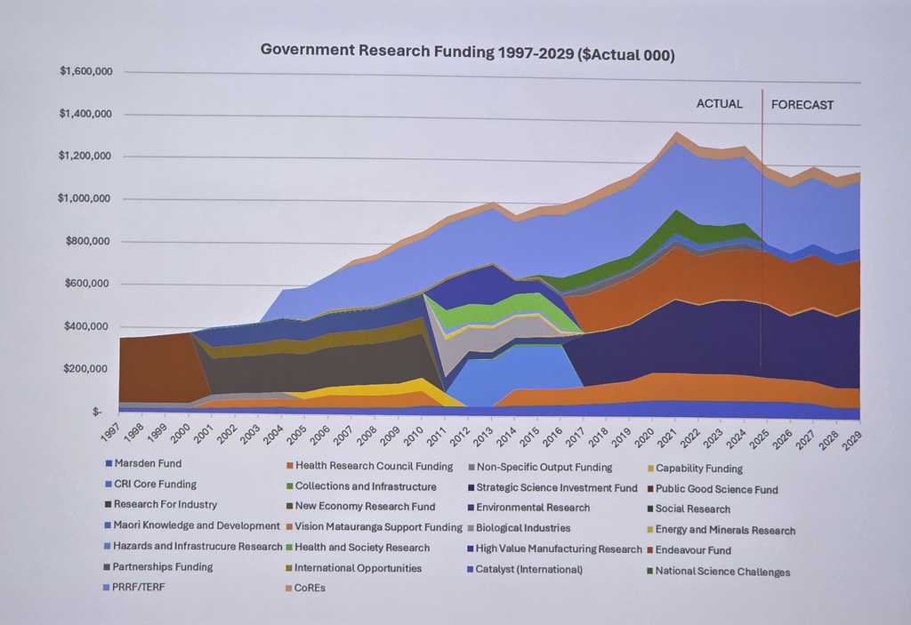

## Visual challenges

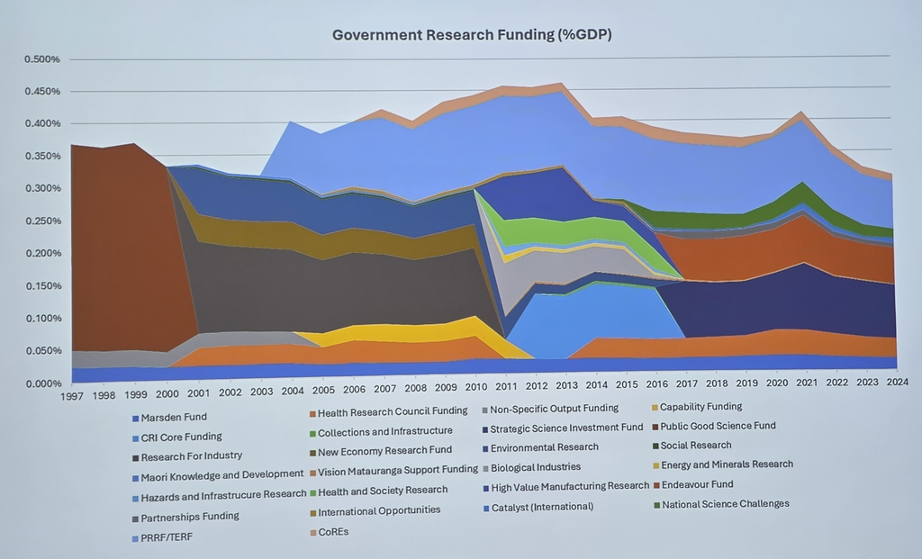

## Suggested improvements

- What’s the goal of the visualisation?
- Who is the audience?
- Less data, less colors = easier to understand
  - lump to fewer categories
  - facet?
- line instead of area?
  - depends on the goal
  - parts of a whole or individual data points

## Statistical considerations with time

## Non-independence

The data collected over time is not independent!

For a lot of your statistical training you would have been taught that independence is a requirement.

Violating this assumption is a no, no

BUT what if the non-independence is the research question?

## Questions about time

What happens to this organism/process/place *over time*?

How does this *change* over time?

How has the environment/measurement/organism changed before and after some event?

## Is my question fixed or random?

- The fixed effects in an experiment are the factors of interest to the researcher; the levels of the factors are specifically chosen to meet the research objectives.
- In contrast, random effects are almost always of little interest to the researcher but are a necessary feature of the experiment.

  This generally means we are more interested in the amount of variation the random effects contribute, and less interested in the specific mean response values for each level of the random effect.

## Fixed versus random effects

A much more common random effect to factor into experiments is the impact of human subjects.

Whether it is clinical trials or product evaluations, it is extremely unusual to be able to bring the exact same set of humans back to repeat the experiment at some future point in time.

It is hoped that the selection of human participants gives the researchers a random sample of people from a wider population. (This might be dubious, but let’s leave that to one side for the moment.)

## Is my factor fixed or random?

- No one answer
- A factor can be fixed in one experiment and random in another
- All in how you are thinking about the question

## Type of data with time

## Repeated measures

- In many studies, we will be repeatedly measuring a response variable over time in a range of test subjects.
- We are interested in the trend shown by each subject, and whether that response differs between treatment groups.
- For our purposes, repeated measures applies only one treatment per subject, then tracks the response for at least n=3 time periods.

## Longitudinal Studies

These experiments which collect data on the same variable over time to compare outcomes are also termed **longitudinal studies**.

Closely related are **cross-sectional studies** which look at different people each time.

Longitudinal studies are widely used in epidemiology, medicine, animal studies and psychology.

Some sources will talk about any design where the same subject is measured multiple times as a repeated measures design, including cases where each treatment is applied to the same person at different times. We will refer to those designs as **crossover designs**. (won’t be covered here)

## Repeated measures

Repeated measures designs are similar to the completely randomized or randomized blocks designs where subjects are randomized to one of several treatments.

The difference is that the response is measured repeatedly throughout the treatment period instead of once at the end of the treatment period.

In theory any design can be a repeated measure.

## Some examples:

- Comparing different weight-loss diets. Human subjects are randomized to one of 3 diets and followed for 3 months recording the weight loss in each week.
- Comparing the effect of seaweed in cattle feed. 20 cows are assigned one of two diets, differing only in the addition of seaweed. The methane emissions of each cow are measured each day for a month.
- Comparing the effects of marine reserves with non-reserve areas. Prior to the establishment of a number of marine reserves, an ecologist begins collecting data on species richness at 10 locations inside and outside the reserves, tracking how they change each year.

## Repeated Measures

One of the advantages of repeated measures designs is that we can estimate the inherent variation within a subject, and separate that from any treatment effect.

Contrast that with a design that only takes a single measurement of each subject; we need a large sample size to determine how much is due to the treatment, and how much to the subject.

## Analyzing Repeated Measures

There are a range of ways to analyse repeated measures data, but the most powerful and flexible is using **mixed models**, which is just a fancy term to say that both fixed and random effects are included in the analysis.

Most longitudinal studies are observational in nature, looking for long-term trends in cohorts, but they can be manipulative experiments, provided subjects are randomly allocated to treatment groups at the start of the study.

## Statistical model

Our exact statistical model will vary depending on the number of factors and nesting, but a good starting model is:

$$y_{ijk}=\mu+\alpha_i + \beta(\alpha)_{j(i)} +\tau_k +\alpha_i \tau_{k}+ \beta(\alpha)\tau_{j(i)k}+\varepsilon_{ijk}$$

where $\alpha_i$ is the treatment effect, and goes from $i=1$ up to $a$ treatment levels

where $\beta_j$ is the subject effect, from $j=1$ up to $b$ subjects, nested in $\alpha_i$

where $\tau$ is the fixed factor ‘time’ with levels $k=1$ up to $t$

## An example: Feeding of dairy cattle

Cows were randomized to receive one of three diets: barley alone, a mixture of barley and lupins, or lupins alone.

Protein was measured in a weekly sample of the milk from each cow for 4 weeks.

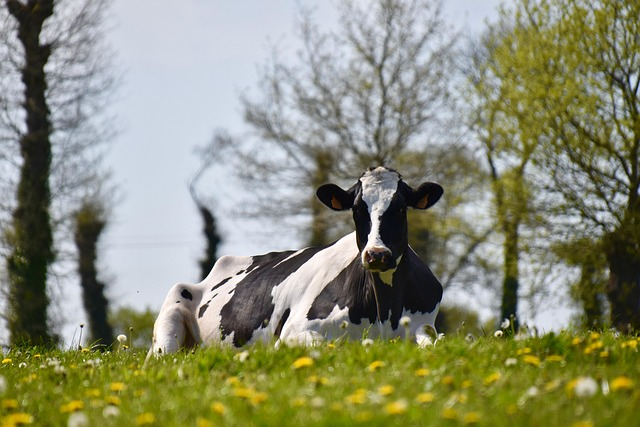

Dairy Cow

## EDA

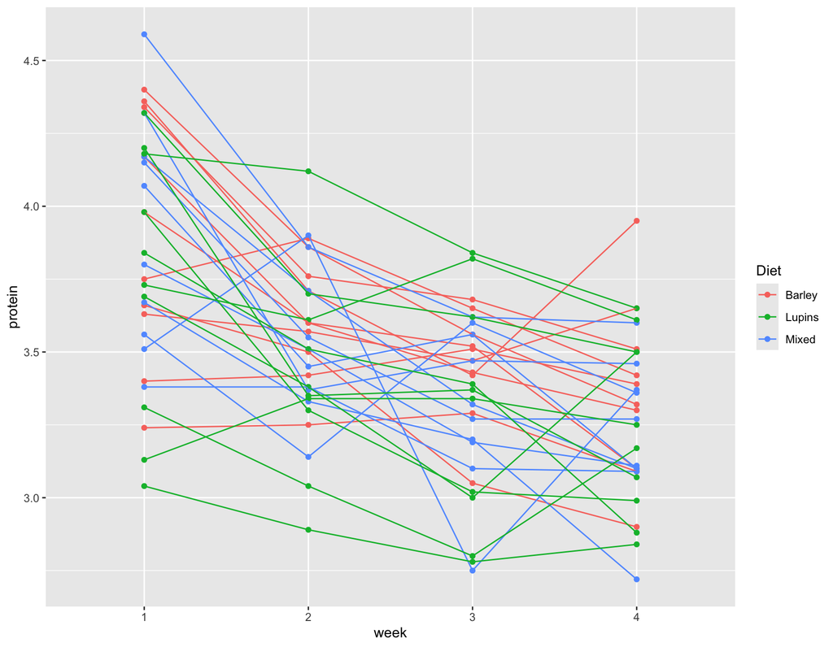

```r
Strung |> ggplot(aes(y=protein, x=week, colour=Diet, group = Cow)) +
  geom_point() +
  geom_line()
```

## EDA

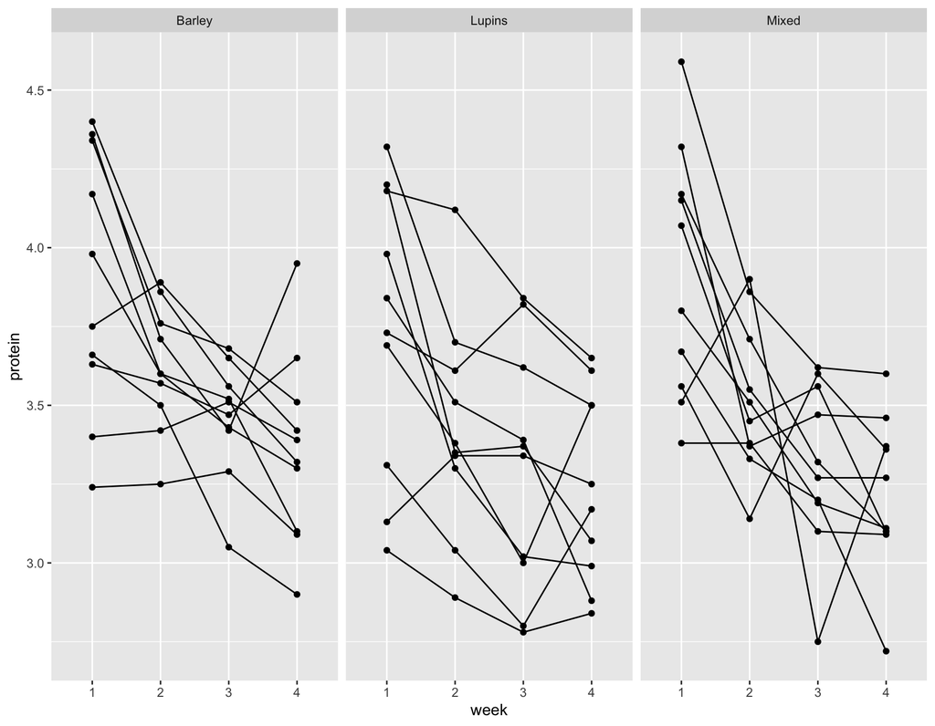

```r
Strung |> ggplot() +
  aes(y=protein, x=week, group = Cow)+
  facet_wrap(~Diet)+
  geom_point() +
  geom_line()
```

## EDA

Remove grouping of cows

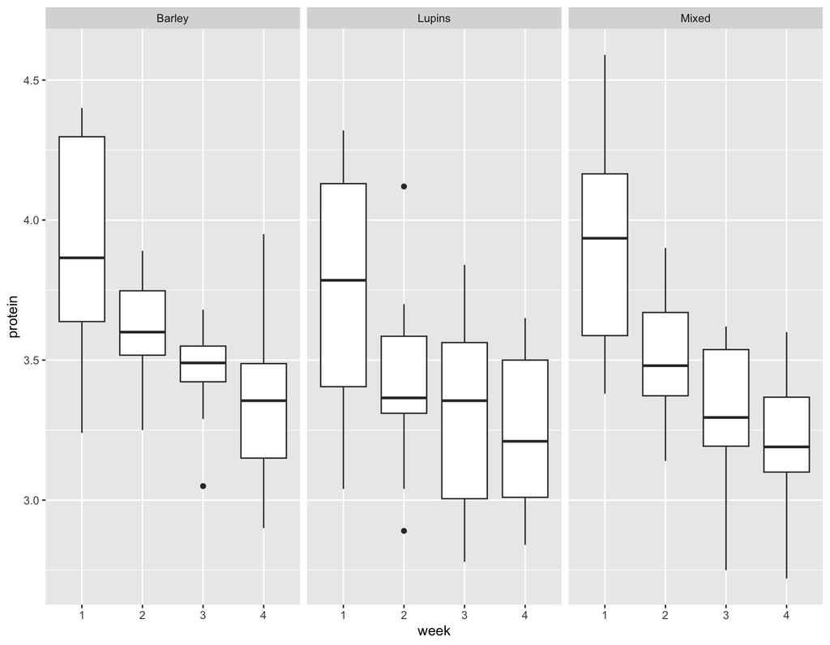

```r
Strung |> ggplot() +
  aes(y=protein, x= week)+
  facet_wrap(~Diet)+
  geom_boxplot()
```

## The model

```r
Strung.lmer =
  lmer(protein ~ Diet*week +
       (Diet|Cow), data = Strung)
```

```
Linear mixed model fit by REML ['lmerMod']
Formula: protein ~ Diet * week + (Diet | Cow)
   Data: Strung

REML criterion at convergence: 58.3

Scaled residuals:
    Min      1Q  Median      3Q     Max
-2.0865 -0.4590 -0.0542  0.5406  1.9643

Random effects:
 Groups   Name        Variance Std.Dev. Corr
 Cow      (Intercept) 0.03486  0.1867
          DietLupins  0.05555  0.2357   -0.01
          DietMixed   0.04388  0.2095   -0.64 -0.10
 Residual             0.05362  0.2316
Number of obs: 120, groups:  Cow, 30

Fixed effects:
                 Estimate Std. Error t value
(Intercept)       3.89300    0.09406  41.387
DietLupins       -0.15100    0.15214  -0.993
DietMixed         0.02900    0.13079   0.222
week2            -0.27700    0.10356  -2.675
week3            -0.43500    0.10356  -4.201
week4            -0.53000    0.10356  -5.118
DietLupins:week2 -0.04100    0.14645  -0.280
DietMixed:week2  -0.12500    0.14645  -0.854
DietLupins:week3 -0.00900    0.14645  -0.061
DietMixed:week3  -0.17900    0.14645  -1.222
DietLupins:week4  0.03400    0.14645   0.232
DietMixed:week4  -0.17400    0.14645  -1.188

Correlation of Fixed Effects:
            (Intr) DtLpns DitMxd week2  week3  week4  DtLp:2 DtMx:2 DtLp:3
DietLupins  -0.618
DietMixed   -0.719  0.445
week2       -0.550  0.340  0.396
week3       -0.550  0.340  0.396  0.500
week4       -0.550  0.340  0.396  0.500  0.500
DitLpns:wk2  0.389 -0.481 -0.280 -0.707 -0.354 -0.354
DietMxd:wk2  0.389 -0.241 -0.560 -0.707 -0.354 -0.354  0.500
DitLpns:wk3  0.389 -0.481 -0.280 -0.354 -0.707 -0.354  0.500  0.250
DietMxd:wk3  0.389 -0.241 -0.560 -0.354 -0.707 -0.354  0.250  0.500  0.500
DitLpns:wk4  0.389 -0.481 -0.280 -0.354 -0.354 -0.707  0.500  0.250  0.500
DietMxd:wk4  0.389 -0.241 -0.560 -0.354 -0.354 -0.707  0.250  0.500  0.250
            DtMx:3 DtLp:4
DietLupins
DietMixed
week2
week3
week4
DitLpns:wk2
DietMxd:wk2
DitLpns:wk3
DietMxd:wk3
DitLpns:wk4  0.250
DietMxd:wk4  0.500  0.500
```

## The results

```r
visreg(Strung.lmer, "Diet", by="week") +
  ylab("Protein")
```

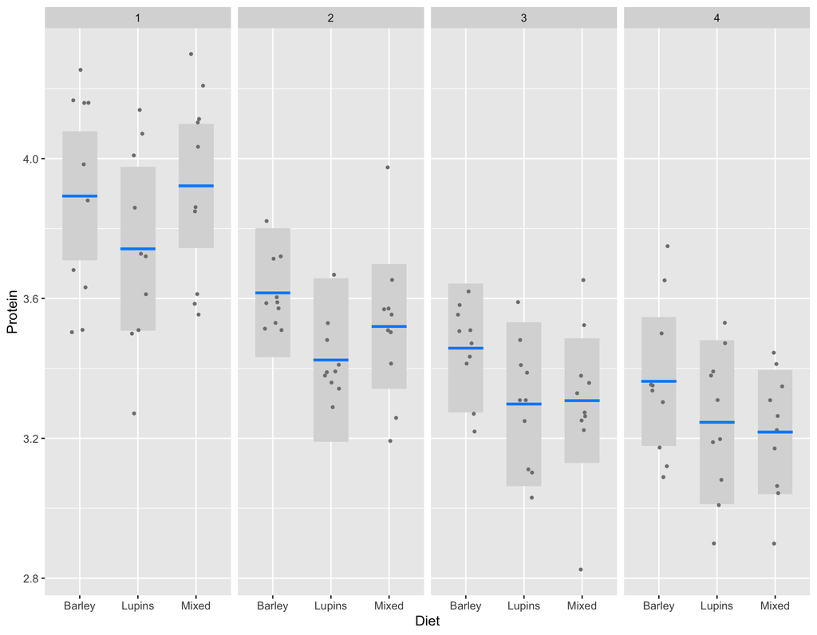

## The results

```r
plot_model(Strung.lmer, show.values=TRUE,
           show.p=TRUE,
           title="sjPlot package output")
```

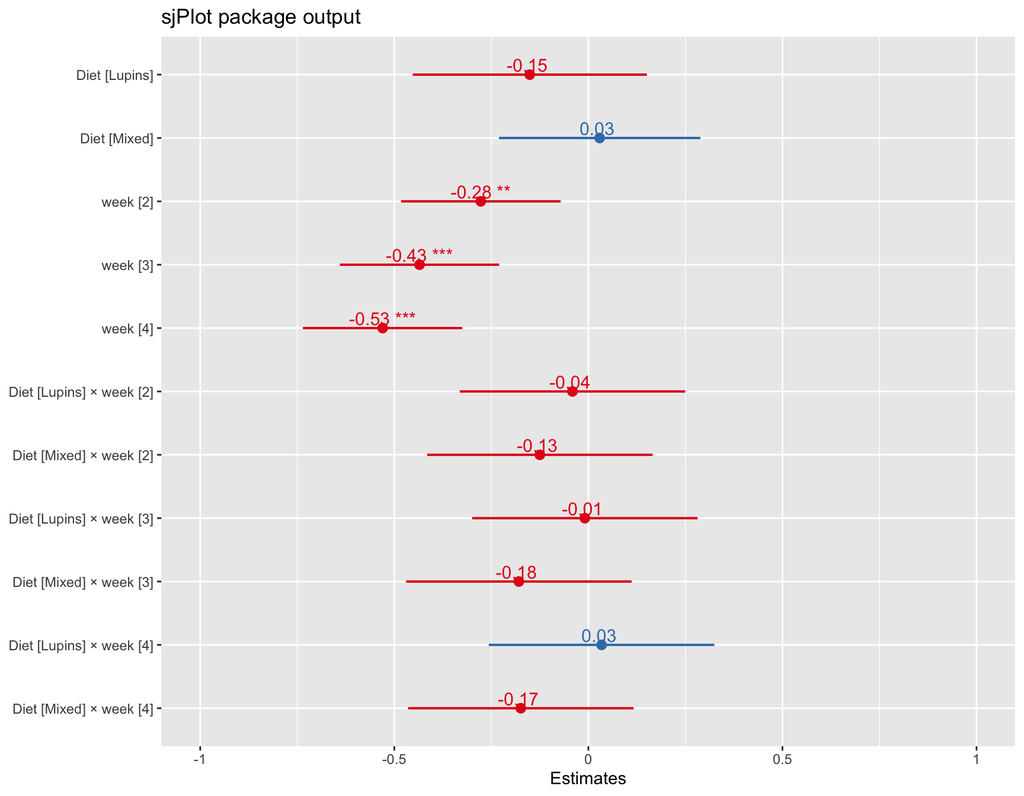

## Residual Plots

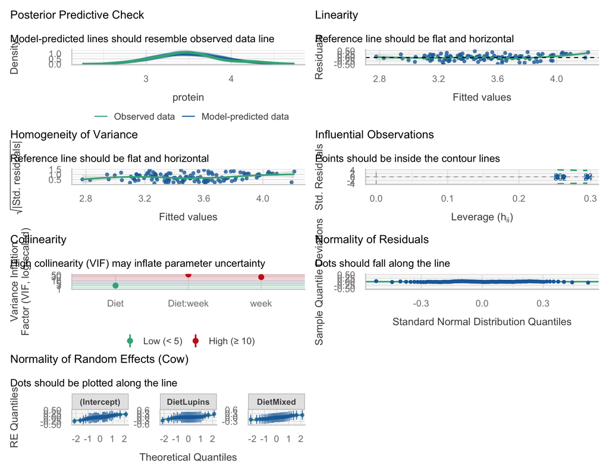

## Interpretation

There is no significant effect of the cows diet on the amount of protein produced. There is no interaction between diet and time.

The amount of protein produced declines on a weekly basis. The difference is significant even 1 week into the diet.

The greatest source of random variation in the model is the variation in cows fed lupins, followed by residual variation. The intercepts for individual cows showed the least variation.

## Summary

- Describe ways time can appear in data
  - **Repeated measures: the same subjects are measured at different times**
  - Time series: the same variable is measured at different times
  - Difference: the difference in the same variable or subject measured at specific times

## Summary

- Characterize visualizations techniques for time data and models with time
  - simple line plots
  - area plots
  - multivariate time plots
  - additions: smoothed lines, facets, etc.

## Summary

- Describe statistical challenges of dealing with data taken over time
  - non independence
  - mixed effect models